# Lesson 124 · Entity vs task table: what question does this row ask?

Teacher reference · Three live functions construct labels, validate task contracts and align predictions. PROVIDED = inspect; TODO = implement; CHECK = execute unchanged; EXIT = defend. Default execution reconstructs all 8,712 task rows, traces a real input subgraph and rescores author predictions; full GPU training is separately gated. Learner status PENDING_WRITTEN_DEFENSE.

```python
# @colab-bootstrap: install missing dependencies; report actual versions.
import importlib.util,importlib.metadata,subprocess,sys
required={'numpy':'numpy','pandas':'pandas','pyarrow':'pyarrow','torch':'torch','torch_frame':'pytorch-frame==0.2.3','torch_geometric':'torch-geometric==2.6.1','relbench':'relbench==1.1.0','pooch':'pooch'}
missing=[package for module,package in required.items() if importlib.util.find_spec(module) is None]
if missing:subprocess.check_call([sys.executable,'-m','pip','install',*missing])
print('Actual notebook runtime:',sys.version)
print({k:importlib.metadata.version(k) for k in ['numpy','pandas','torch','pytorch-frame','torch-geometric','relbench']})
```

```
Actual notebook runtime: 3.12.3 (main, Aug 31 2026, 10:18:26) [GCC 13.3.0]
{'numpy': '2.5.0', 'pandas': '3.0.3', 'torch': '2.13.0+cpu', 'pytorch-frame': '0.3.0', 'torch-geometric': '2.8.0.post1', 'relbench': '1.1.0'}
```

From Lesson 123 to this lesson

The legal context is defined, but it does not say what to predict. A task table connects entity-time questions to future outcomes.

**Quick prerequisite reminder**

An entity row describes one object. A task row describes one prediction request. A prediction horizon defines the future interval from which its label is built.

## 1 · The graph exists. What exactly are we predicting?

[Lesson 122](https://avistian.github.io/relational/lessons/0122-reg-construction.html) built a relational entity graph (REG): each database row became a typed node, and foreign keys became edges. [Lesson 123](https://avistian.github.io/relational/lessons/0123-temporal-heterogeneous-graphs.html) constrained a query's neighborhood to its prediction time. Neither choice determines the target. The same driver node could support predicting finishing position, retirement, or a qualifying result. A **task table** supplies that missing contract.

**Your tangible win:** specify a task as `(entity, prediction time, label)`, build its labels, and trace one row to a supervised prediction. Your notebook implements three functions that also run against the full released F1 task data. The core path is Sections 1–6; the reproduction and source audit are a second sitting.

This is central to our [mission](https://avistian.github.io/relational/MISSION.md): a lower error only supports the RDL thesis when we can state which prediction problem produced it. Good graph construction cannot repair a target that silently changes with row order or uses the wrong time horizon.

Primary reading: [Fey et al., RDL blueprint, Sections 3–4](https://proceedings.mlr.press/v235/fey24a.html). For the measured experiment, read [Robinson et al., RelBench v1, task definitions and Table 7](https://arxiv.org/html/2407.20060v1). These are distinct papers; the numerical target here comes from RelBench v1.

## 2 · One entity row can support many prediction rows

| Table | Row means | Identity | Used for |
| --- | --- | --- | --- |
| Entity table: drivers | One driver | driverId | Reusable graph node and attributes |
| Task table: driver-position | One question about a driver at a cutoff | (driverId, date) within this task | Seed selection, seed time, supervised target |
| Event table: results | One recorded race result | resultId | Historical context or future label evidence, depending on cutoff |

For several tasks or horizons, extend query identity with the task/horizon ID. An entity-only dictionary loses repeated questions about the same person. A dataframe row number is merely storage order: shuffling predictions must not change a correctly aligned metric.

A task table's `driverId` references the entity table. It does **not** make the task's future `position` an input feature. In the released entity-task interface, the entity table, entity column, time column and target column are explicit metadata. [Pinned task source](https://github.com/snap-stanford/relbench/blob/9aa346267c2e1c560bd92da07d6f4ad1ca2f0639/relbench/tasks/f1.py).

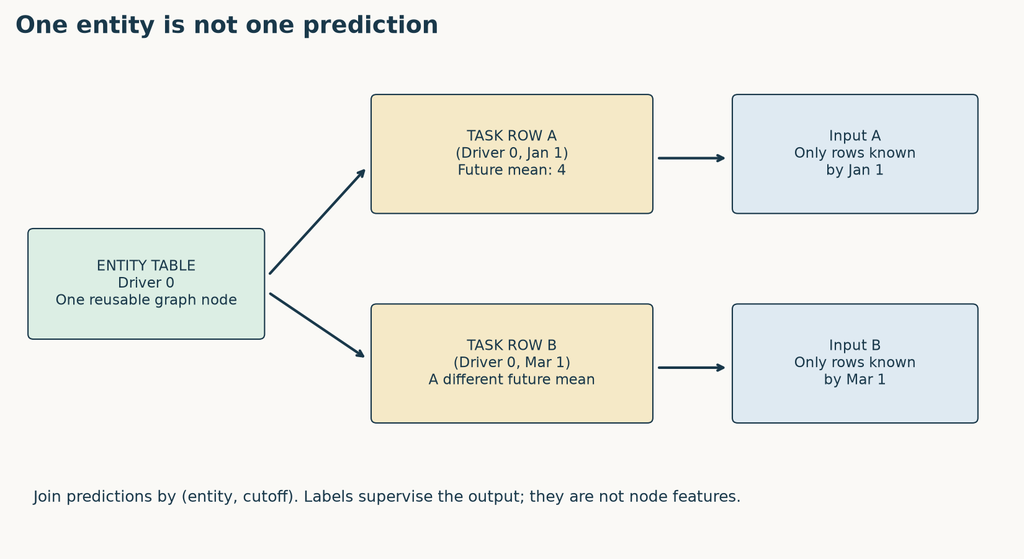

One driver node supports separate task rows at separate cutoffs. The task row selects the seed and supervision; its label is not a graph feature.

**Predict:** Driver 0 appears at January 1 and March 1. How many graph entities, queries and labels does this describe? One entity, two queries and two labels. The two sampled computation graphs can differ because their cutoffs differ.

## 3 · Construct a label without constructing leakage

The released `driver-position` task predicts mean `positionOrder` over events in **(t, t + 60 days]**. “Two months” in the source description is implemented as 60 days, not two calendar months. A race exactly at t is outside the label; one at t + 60 days is inside. [Released SQL](https://github.com/snap-stanford/relbench/blob/9aa346267c2e1c560bd92da07d6f4ad1ca2f0639/relbench/tasks/f1.py).

Keep three operations separate:

1. **Choose the cohort:** decide which entities receive a prediction at t.
2. **Build model input:** use only information available at t, as in L123.
3. **Observe the target later:** aggregate outcomes in the declared future window.

Future outcomes are legitimate label evidence. Feeding them into the row encoder or letting them decide a supposedly past-known cohort changes the problem.

In the toy example, Driver 0 has positions 99 on day 0, 2 on day 1, and 6 on day 60. Driver 1 first appears on day 2 with position 3. At t = day 0, the first driver's label is `(2 + 6) / 2 = 4`, not `(99 + 2 + 6) / 3`. Driver 1 has an observed future label of 3, but no past result at t.

Static trace: at day0, past activity admits Driver0 with future positions2 and6: mean4. Released-style eligibility also admits Driver1 with future position3. No future event means no observed mean, not zero.

**Task 1 — `make_labels`:** implement the open-left, closed-right window and the two explicit cohort choices. The released eligibility SQL requires a result after `t - INTERVAL '1 year'` with no upper bound. Because each emitted row already has a future result, that condition does not enforce past activity. The `past` exercise adds `date <= t` to eligibility. It retains the future outcome window unchanged.

The load-bearing window is visible in the implementation:

```
end = t + pd.Timedelta(days=60)
in_window = results.date.gt(t) & results.date.le(end)
# Aggregate only after applying the declared cohort and this window.
```

This is a source observation, not a claim that feature tensors contain future labels. The benchmark's observed-outcome population and a deployment cohort can differ. Even the `past` exercise only emits drivers with future races; it therefore remains conditioned on observed participation. A deployment design must separately decide what to return when a driver does not race.

No future race means **no observed mean**, not a mean position of zero. Likewise, an unfinished observation window must not be treated as a completed negative outcome. For a 60-day target we conservatively require full window completion; with reporting delays the maturity time can be later than t + 60 days.

## 4 · A task table is a contract you can check

**Task 2 — `validate_task`:** check entity references, unique `(driverId, date)` pairs, finite labels, and a label end after the cutoff. At training time, additionally require `label_end <= fit_time`. The latter assumes outcomes arrive by the window end in our exercise; real ingestion delays require an observed availability clock.

The two checks answer different questions:

```
# Repeated entities are allowed; repeated questions are not.
assert not rows.duplicated(["driverId", "date"]).any()
# Under our no-delay exercise contract:
assert rows.label_end.le(fit_time).all()
```

A chronological split should be justified using both query times and label windows. If a query is dated before the fitting cutoff but its label matures afterwards, its target was not available for that fit. Selecting a model on validation labels also requires those labels to have matured before the claimed selection time.

**Chronological query dates can still have overlapping label windows.** Reuse Driver0's outcomes: position 2 on day1 and position 6 on day60. Assume the complete event record is observed through day90 and contains no other races after day0:

| Query day | Target interval | Mean | Mature on |
| --- | --- | --- | --- |
| 0 | (0, 60] | 4 | 60 |
| 30 | (30, 90] | 6 | 90 |

The day60 race contributes to both labels. Distinct query keys do not imply independent outcomes. More urgently, a model fitted to predict on day30 cannot train on the day0 label: its window is unfinished. Sorting query dates alone would miss this problem. The day30 label also stays immature until day90 under our full-window contract, even though its last recorded race is on day60.

**Try the split.** Move the later prediction cutoff from day30 to day60. Is the day0 training label mature under the no-delay convention? Does the race on day60 belong to the later target window?

**Check the window boundary**

The earlier label is mature at day60, assuming all its outcomes are available then. The later target window is (60,120], so it excludes the day60 race. These boundary checks address this window overlap; they do not establish independence across drivers, races, or other shared context.

The pinned split builder generates training cutoffs backwards from `validation_start - 60 days`; validation cutoffs stop no later than `test_start - 60 days`; test cutoffs stop before the database's final complete 60-day horizon. Empty windows can produce no task rows. [Pinned split builder](https://github.com/snap-stanford/relbench/blob/9aa346267c2e1c560bd92da07d6f4ad1ca2f0639/relbench/base/task_base.py).

**Complete task reconstruction: PASS — all 8,712 rows.**

| Split | Task rows | Grid cutoffs | Nonempty cutoffs | Rows excluded by past-only activity |
| --- | --- | --- | --- | --- |
| train | 7453 | 332 | 254 | 955 |
| val | 499 | 30 | 23 | 33 |
| test | 760 | 40 | 33 | 42 |

[Independent task audit](https://avistian.github.io/relational/labs/_task_audit_l124_results.json). Past-only counts are a course intervention, not a changed benchmark score.

The comparison uses the full grid, including cutoffs that emit no rows. Identities agree exactly with both original SQL and the archive; numerical comparisons use absolute tolerance 1e-12. The exported notebook contains all 26,080 result events and released task rows, so your implementation repeats this check without accessing this repository.

## 5 · Model architecture: from one task row to one training loss

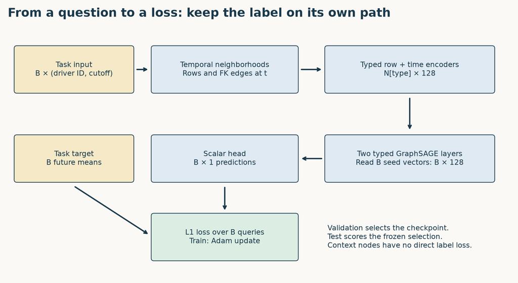

Task input drives temporal sampling, typed width-128 encoding, two GraphSAGE layers and a scalar seed head. Future labels enter only the loss branch.

**Diagram trace.** Follow one task row to one root output and one loss term. Why are context nodes not extra supervised examples? On a narrow screen, scroll the figure sideways.

Trace a batch of B entity queries:

1. Map each task row's foreign key to a driver node. Preserve its query ID and cutoff.
2. Sample that driver's temporal neighborhood, keeping the root cutoff at every hop. Two questions about the same driver remain distinct query contexts.
3. Encode each sampled table's attributes into width-128 vectors; add relative-time encodings for dated rows.
4. Apply two typed GraphSAGE layers. Within-relation aggregation and across-relation combination follow the released model.
5. Read the first B **seed** driver embeddings, apply the scalar head, and pair the B outputs with those task rows' B targets. Context drivers do not gain supervised targets just by appearing in the neighborhood.
6. Minimize mean absolute error over training queries. Choose the checkpoint using validation MAE, then score the frozen selection on test queries.

The released trainer makes the supervision path inspectable:

```
pred = model(batch, task.entity_table).view(-1)
loss = torch.nn.functional.l1_loss(
    pred.float(), batch[task.entity_table].y.float()
)
loss.backward()
optimizer.step()
```

Here the model returns seed outputs, and the task transform attaches seed targets. The outer training loop zeroes gradients before this fragment.

The notebook includes the complete visible model/trainer and original-source parity checks. It also uses L123's full graph payload to show one real labeled task row and its exact two-hop input neighborhood. The toy exhaustive sampler is for reasoning; the fresh experiment uses the release's bounded uniform fanouts `[128, 64]`.

**Task 3 — `aligned_mae`:** join predictions to labels by `(driverId, date)`, reject duplicate/missing/extra queries, and score the join. Our toy predictions arrive in reversed order: labels 4 and 3, predictions 5 and 5, MAE 1.5. The notebook then shuffles every real validation/test prediction table and checks all five author runs using your function.

## 6 · Entity tasks, link tasks, and temporal tasks

“Temporal” describes how information and targets depend on time; it is not an alternative to entity versus link prediction. F1 driver-position is both an entity task and a temporal task.

| Task family | Query | Target | Readout |
| --- | --- | --- | --- |
| Entity regression | (driver, t) | Future mean position | One seed vector → scalar |
| Entity classification | (customer, t) | Future churn event | One seed vector → probability |
| Link prediction | (source, candidate destination, t), or source with a candidate set | Future relationship | Pair score or candidate ranking |

For link tasks, candidate eligibility, negatives and the horizon are part of the task contract. Revisit [L087](https://avistian.github.io/relational/lessons/0087-link-prediction.html) for link setup; this lesson does not train a link model. L125 will turn typed database columns into row features; L128 will build on this separation between the reusable graph and task-specific supervision.

## 7 · Full selected-experiment reproduction

**Fresh author-reference execution: COMPLETE selected released-protocol experiment.**

| Split | Mean MAE | Sample seed SD | Published mean | Verdict |
| --- | --- | --- | --- | --- |
| val | 3.179653 | 0.040714 | 3.193 | CLOSE |
| test | 4.018438 | 0.102607 | 4.022 | CLOSE |

| Seed | Selected epoch | Validation MAE | Test MAE |
| --- | --- | --- | --- |
| 0 | 9 | 3.133287 | 3.917070 |
| 1 | 8 | 3.158849 | 4.109376 |
| 2 | 8 | 3.177878 | 3.896669 |
| 3 | 10 | 3.185244 | 4.085310 |
| 4 | 7 | 3.243005 | 4.083766 |

All **6,295** final predictions were independently scored. Maximum original-model output discrepancy: **2.86e-06**. Measured pilot plus full-fit worker resource estimate: **USD 0.0539**, excluding unitemized overhead. The aggregate plan caps reservations plus overhead reserve at USD 10. [Evidence](https://avistian.github.io/relational/labs/evidence/l124/summary.json).

All sampled batches also passed the inherited root-time/edge/query-isolation audit: **403,895 query occurrences**, including repeated epochs. Availability and historical feature values remain unobserved.

These are **fresh full-data author runs**, not a longer toy fit or reused checkpoint. The target is the selected RelBench v1 Table 7 RDL driver-position experiment. Five seeds × ten complete epochs use all 7,453 training queries, with first-best validation selection. All 6,295 final predictions are independently rescored and replayed through the original model on the same sampled batches.

The protocol retains the release's preprocessing through the test cutoff, declared seeds, current pinned runtime, source fanouts and outcome-conditioned cohort. These differences and missing historical details prevent a claim of exact historical reproduction or whole-paper parity. A descriptive mean tolerance of 0.2 MAE was declared before the new scores; it is not a statistical equivalence test. Seed SD measures training variability conditional on this dataset and protocol, not uncertainty over future databases.

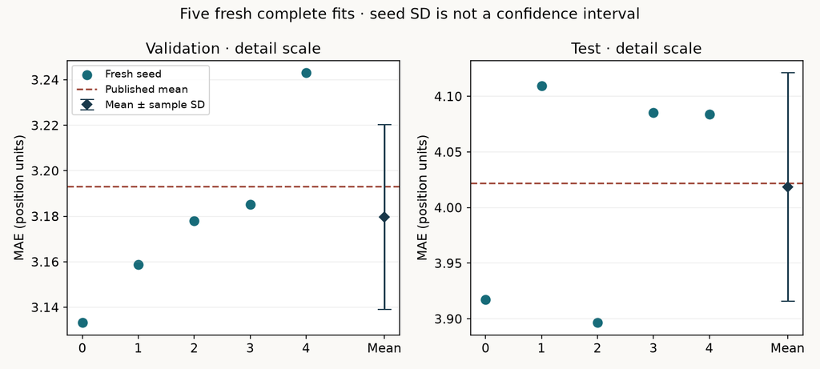

Five fresh complete fits; diamonds and bars show mean plus or minus sample seed SD. Dashed lines are published targets. Detail scales differ.

[Exact commands and deviations](https://avistian.github.io/relational/labs/l124-reproduction.md) · [Visible task implementation](https://avistian.github.io/relational/labs/relkit/tasks_l124.py) · [Visible full RDL implementation](https://avistian.github.io/relational/labs/relkit/rdl_l117.py) · [Source manifest](https://avistian.github.io/relational/labs/_sources_l124.json) · [Budget ledger](https://avistian.github.io/relational/labs/_budget_l124.json).

## 8 · Practice, defend, return

[Open student notebook](https://avistian.github.io/relational/labs/0124-entity-task-tables.ipynb) · [Executed reference](https://avistian.github.io/relational/labs/html/0124-entity-task-tables.html) · [Solution notebook](https://avistian.github.io/relational/labs/solutions/0124-entity-task-tables.ipynb) · [Reference card](https://avistian.github.io/relational/reference/entity-task-tables.html).

**TODO:** implement the three functions before consulting the solution. **CHECK:** run the unchanged boundary tests, reconstruct all task rows and rescore the shuffled real predictions. **EXIT:** submit a written task specification and one annotated real example subgraph, then answer:

1. Why do two cutoffs for one entity require two supervised examples?
2. Which outcome events form your label, and which rows can the input see?
3. Why does the released activity predicate fail to establish past activity? What remains outcome-conditioned after adding the upper bound?
4. What happens to a query with no future event, or with an immature target?
5. Why are an exact task-table reconstruction and a close benchmark mean different evidence?

Tomorrow, reconstruct the window without notes. In a week, transfer the contract to a customer/churn task and specify the no-event meaning. **Author execution is not learner mastery: PENDING_WRITTEN_DEFENSE.** Ask the teaching agent follow-up questions about any unclear window, identity, source discrepancy or tensor path.

Explain the difference between future label evidence and information available for a prediction.

**Carry this forward.** Turn the allowed mixed-type feature columns into trainable row vectors. [Continue to Lesson 125](https://avistian.github.io/relational/lessons/0125-pytorch-frame-deep-dive.html).

### Imports (PROVIDED)

```python
import json
import math
import pandas as pd
```

### Future labels (TODO 1)

Construct future means with explicit released/past cohort choice. Hint: separate eligibility, window bounds and aggregation. Implement this function, then run its unchanged CHECK. The toy trace and full F1 task harness call your function.

```python
def make_labels(results, cutoffs, cohort='released'):
    """Mean future position in (t,t+60d]; absent outcome produces no row.

    released: literal source eligibility date > t - one calendar year.
    past: additionally require eligibility observation date <= t.
    Neither mode invents a zero outcome for a driver with no future races.
    """
    if cohort not in ('released','past'):
        raise ValueError('Unknown cohort')
    cutoffs=pd.DatetimeIndex(cutoffs)
    if cutoffs.has_duplicates or cutoffs.isna().any():
        raise ValueError('Cutoffs must be unique and known')
    if results[['driverId','date','positionOrder']].isna().any().any():
        raise ValueError('Missing event identity/time/outcome')
    rows=[]
    for t in cutoffs:
        end=t+pd.Timedelta(days=60)
        active=results.date.gt(t-pd.DateOffset(years=1))
        if cohort=='past':active &= results.date.le(t)
        ids=set(results.loc[active,'driverId'])
        future=results.loc[results.date.gt(t)&results.date.le(end)&results.driverId.isin(ids)]
        for entity,value in future.groupby('driverId',sort=True).positionOrder.mean().items():
            rows.append(dict(driverId=int(entity),date=t,position=float(value),label_end=end))
    return pd.DataFrame(rows,columns=['driverId','date','position','label_end'])
```

```python
def check_labels(fn):
    t=pd.Timestamp('2020-01-01')
    r=pd.DataFrame({'driverId':[0,0,0,0,1,2], 'date':[t,t+pd.Timedelta(days=1),t+pd.Timedelta(days=60),t+pd.Timedelta(days=61),t+pd.Timedelta(days=2),t-pd.Timedelta(days=400)], 'positionOrder':[99,2,6,99,3,9]})
    a=fn(r,[t]);b=fn(r,[t],cohort='past')
    assert a[['driverId','position']].values.tolist()==[[0,4.],[1,3.]]
    assert b[['driverId','position']].values.tolist()==[[0,4.]]
    assert (a['label_end']==t+pd.Timedelta(days=60)).all()
    assert fn(r,[t+pd.Timedelta(days=500)]).empty
    assert len(fn(r.sample(frac=1,random_state=3),[t]))==2
    try:fn(r,[t,t])
    except ValueError:pass
    else:raise AssertionError('Duplicate cutoffs accepted')
check_labels(make_labels)
print("PASS: make_labels")
```

```
PASS: make_labels
```

### Task contract (TODO 2)

Check query identity, entity references and label maturity. Hint: entity repetition is legal; query repetition is not. Implement this function, then run its unchanged CHECK. The toy trace and full F1 task harness call your function.

```python
def validate_task(rows, entity_ids, fit_time=None):
    """Validate labeled queries; fit_time additionally requires mature labels."""
    required=['driverId','date','position','label_end']
    if not set(required).issubset(rows.columns) or rows[required].isna().any().any():
        raise ValueError('Task fields missing')
    if rows.duplicated(['driverId','date']).any():
        raise ValueError('Duplicate entity/time query')
    if not rows.driverId.isin(set(entity_ids)).all():
        raise ValueError('Dangling prediction entity')
    if not all(math.isfinite(float(v)) for v in rows.position):
        raise ValueError('Nonfinite target')
    if not rows.label_end.gt(rows.date).all():
        raise ValueError('Label horizon must end after query')
    if fit_time is not None and not rows.label_end.le(pd.Timestamp(fit_time)).all():
        raise ValueError('Labels not mature at fit time')
    return len(rows)
```

```python
def check_validate(fn):
    t=pd.Timestamp('2020-01-01');end=t+pd.Timedelta(days=60)
    rows=pd.DataFrame({'driverId':[0,0],'date':[t,t+pd.Timedelta(days=60)],'position':[4.,5.],'label_end':[end,end+pd.Timedelta(days=60)]})
    assert fn(rows,[0])==2
    assert fn(rows.iloc[:1],[0],fit_time=end)==1
    for bad,ids,fit in [(pd.concat([rows,rows.iloc[:1]]),[0],None),(rows,[1],None),(rows,[0],end),(rows.assign(position=float('nan')),[0],None),(rows.assign(label_end=t),[0],None)]:
        try:fn(bad,ids,fit)
        except ValueError:pass
        else:raise AssertionError('Invalid task accepted')
check_validate(validate_task)
print("PASS: validate_task")
```

```
PASS: validate_task
```

### Query-key alignment (TODO 3)

Score by query keys after deliberately shuffling predictions. Hint: require a one-to-one outer join with complete coverage. Implement this function, then run its unchanged CHECK. The toy trace and full F1 task harness call your function.

```python
def aligned_mae(rows, predictions):
    """Score by (entity,time), never by an entity-only map or row coincidence."""
    keys=['driverId','date']
    for frame in (rows,predictions):
        if frame[keys].isna().any().any() or frame.duplicated(keys).any():
            raise ValueError('Invalid query identity')
    joined=rows.merge(predictions,on=keys,how='outer',validate='one_to_one',indicator=True)
    if len(joined)==0 or not joined['_merge'].eq('both').all():
        raise ValueError('Prediction coverage differs')
    if not all(math.isfinite(float(v)) for col in ['position','prediction'] for v in joined[col]):
        raise ValueError('Nonfinite score inputs')
    return math.fsum(abs(float(p)-float(y)) for p,y in zip(joined.prediction,joined.position))/len(joined)
```

```python
def check_alignment(fn):
    t=pd.Timestamp('2020-01-01');u=t+pd.Timedelta(days=60)
    rows=pd.DataFrame({'driverId':[0,0],'date':[t,u],'position':[2.,6.]})
    preds=pd.DataFrame({'driverId':[0,0],'date':[u,t],'prediction':[5.,4.]})
    assert fn(rows,preds)==1.5
    for bad in [preds.iloc[:1],pd.concat([preds,preds.iloc[:1]]),preds.assign(prediction=float('nan'))]:
        try:fn(rows,bad)
        except ValueError:pass
        else:raise AssertionError('Bad prediction identity accepted')
check_alignment(aligned_mae)
print("PASS: aligned_mae")
```

```
PASS: aligned_mae
```

### Course trace (PROVIDED)

```python
def course_run():
    t=pd.Timestamp('2020-01-01')
    events=pd.DataFrame({'driverId':[0,0,0,1],'date':[t,t+pd.Timedelta(days=1),t+pd.Timedelta(days=60),t+pd.Timedelta(days=2)],'positionOrder':[99,2,6,3]})
    rows=make_labels(events,[t]);validate_task(rows,[0,1],t+pd.Timedelta(days=60))
    predictions=rows[['driverId','date']].iloc[::-1].copy();predictions['prediction']=[5.,5.]
    score=aligned_mae(rows,predictions)
    assert score==1.5
    return dict(status='PASS',released_rows=len(rows),past_rows=len(make_labels(events,[t],'past')),mae=score,learner_status='PENDING_WRITTEN_DEFENSE')
```

## RUN · your task-table contract

Predict which driver receives a label before execution. The report proves reference execution, not learner mastery.

```python
report=course_run()
from pathlib import Path
Path('l124-task-report.json').write_text(json.dumps(report,indent=2))
print(json.dumps(report,indent=2))
```

```
{
  "status": "PASS",
  "released_rows": 2,
  "past_rows": 1,
  "mae": 1.5,
  "learner_status": "PENDING_WRITTEN_DEFENSE"
}
```

## Audit the real author runs

The embedded predictions are from five fresh full-data fits. They do not replace your own training evidence.

```python
# PROVIDED: your query-key scorer consumes all fresh author predictions.
import numpy as np,io,base64,hashlib
payload = {'0': {'base64': 'UEsDBC0AAAAIAAAAIQAx8Ee4//////////8MABQAdmFsX3ByZWQubnB5AQAQ…==', 'sha256': '7331287966c6697a7c41ab3db7d44c3ba30a96e56d0c063e28ee179e213d26b0'}, '1': {'base64': 'UEsDBC0AAAAIAAAAIQA7xGlk//////////8MABQAdmFsX3ByZWQubnB5AQAQ…==', 'sha256': '45c2827c09efe7dca66a0b761da6270da9afa205334d3a464f3d52878a533c49'}, '2': {'base64': 'UEsDBC0AAAAIAAAAIQCgD2dF//////////8MABQAdmFsX3ByZWQubnB5AQAQ…=', 'sha256': '25a92fafe51102bf5f9f19bb78e5e6d09f155624c535dfe2bc6f2d4e293cbc92'}, '3': {'base64': 'UEsDBC0AAAAIAAAAIQBqhkGn//////////8MABQAdmFsX3ByZWQubnB5AQAQ…', 'sha256': '76e538833087f250a0e8d8718215c5455e3e57c7407b1ea75347812acd2f4abd'}, '4': {'base64': 'UEsDBC0AAAAIAAAAIQD1oO7r//////////8MABQAdmFsX3ByZWQubnB5AQAQ…', 'sha256': '43a997ade1913f7939a6a100ccb3f2863f5839de247395433da0b8ef470edf09'}}
expected = [{'seed': 0, 'selected_epoch': 9, 'val': 3.133287431529624, 'test': 3.9170695578424555}, {'seed': 1, 'selected_epoch': 8, 'val': 3.158848838959046, 'test': 4.10937595534743}, {'seed': 2, 'selected_epoch': 8, 'val': 3.1778783622390043, 'test': 3.8966694205267385}, {'seed': 3, 'selected_epoch': 10, 'val': 3.185244450795308, 'test': 4.085310389075363}, {'seed': 4, 'selected_epoch': 7, 'val': 3.2430054525096335, 'test': 4.08376590628373}]
for seed,item in payload.items():
    raw=base64.b64decode(item['base64']);assert hashlib.sha256(raw).hexdigest()==item['sha256']
    arrays=np.load(io.BytesIO(raw),allow_pickle=False)
    for split in ['val','test']:
        rows=pd.DataFrame({'driverId':arrays[split+'_entity'], 'date':pd.to_datetime(arrays[split+'_time']), 'position':arrays[split+'_target']})
        predictions=rows[['driverId','date']].copy();predictions['prediction']=arrays[split+'_pred'];predictions=predictions.sample(frac=1,random_state=124)
        mae=aligned_mae(rows,predictions)
        assert abs(mae-expected[int(seed)][split])<1e-12
        print(seed,split,mae)
print('6,295 fresh author predictions rescored by your function; this cell does not train.')
```

```
0 val 3.133287431529624
0 test 3.9170695578424555
1 val 3.158848838959046
1 test 4.10937595534743
2 val 3.1778783622390043
2 test 3.8966694205267385
3 val 3.185244450795308
3 test 4.085310389075363
4 val 3.2430054525096335
```

```
4 test 4.08376590628373
6,295 fresh author predictions rescored by your function; this cell does not train.
```

## Reconstruct all released task rows

Your functions process the complete result events and all split cutoffs. Source SQL was checked separately in the author audit.

```python
# PROVIDED harness: all events and task rows, called through your functions.
import gzip,base64,hashlib,numpy as np
raw=base64.b64decode('H4sIAAAAAAACA6y9vc44u6+ddy//2m8gUR+Uzh2kSpMuVYBzCjd2YBtugtx7…=');assert hashlib.sha256(raw).hexdigest()=='139862da5d51b91c5a988587438ef2397ff9b6e6417fd93d9c1453850b4e8f8a'
real=json.loads(gzip.decompress(raw));events=pd.DataFrame(real['events']);events['date']=pd.to_datetime(events.date)
all_rows={}
for split,spec in real['splits'].items():
    source=events if spec['db_cutoff'] is None else events[events.date<=pd.Timestamp(spec['db_cutoff'])]
    rows=make_labels(source,pd.to_datetime(spec['cutoffs']))
    rows=rows[rows.driverId.isin(real['entity_ids'])]
    validate_task(rows,real['entity_ids'],real['val_timestamp'] if split=='train' else None)
    expected=pd.DataFrame(spec['expected']);expected['date']=pd.to_datetime(expected.date)
    a=rows.sort_values(['date','driverId']).reset_index(drop=True);b=expected.sort_values(['date','driverId']).reset_index(drop=True)
    pd.testing.assert_frame_equal(a[['driverId','date']],b[['driverId','date']],check_dtype=False)
    np.testing.assert_allclose(a.position,b.position,rtol=0,atol=1e-12)
    past=make_labels(source,pd.to_datetime(spec['cutoffs']),'past')
    print(split,len(rows),'rows exactly reconstructed;',len(rows)-len(past),'excluded by past activity')
    all_rows[split]=rows
assert sum(map(len,all_rows.values()))==8712
```

```
train 7453 rows exactly reconstructed; 955 excluded by past activity
val 499 rows exactly reconstructed; 33 excluded by past activity
test 760 rows exactly reconstructed; 42 excluded by past activity
```

## PROVIDED · temporal sampler from L123

Reused visibly to construct the input for one real task row.

```python
"""Inspectable query-time graph operations; explicit temporal contracts."""
# %% PROVIDED: dependencies
import json
import math

# %% PROVIDED: worked fixture

def fixture():
    # None means explicitly assumed timeless, not an unknown timestamp.
    nodes = {('person',0):None, ('transfer',0):(4,4),
             ('transfer',1):(9,9), ('transfer',2):(5,11),
             ('memo',0):(12,12), ('memo',1):(7,7)}
    edges = [dict(src=('transfer',i),dst=('person',0),kind='receiver',stamp=None) for i in range(3)]
    edges += [dict(src=('memo',i),dst=('transfer',0),kind='describes',stamp=None) for i in range(2)]
    return nodes,edges



# %% Task 1: visibility at one query cutoff
def eligible(stamp, cutoff):
    if not math.isfinite(cutoff):
        raise ValueError('Cutoff must be finite')
    if stamp is None:
        return True
    event, available = stamp
    if any(x is None or not math.isfinite(x) for x in stamp) or available < event:
        raise ValueError('Explicit finite event <= availability times required')
    return event <= cutoff and available <= cutoff

# %% Task 2: incoming multi-hop temporal neighborhood
def sample_temporal(nodes, edges, root, cutoff, hops=2):
    if not isinstance(hops,int) or hops < 0:
        raise ValueError('Nonnegative integer hop count required')
    if root not in nodes or not eligible(nodes[root],cutoff):
        raise ValueError('Root does not exist at query time')
    incoming = {}
    for i,e in enumerate(edges):
        if e['src'] not in nodes or e['dst'] not in nodes:
            raise ValueError('Unknown edge endpoint')
        incoming.setdefault(e['dst'],[]).append(i)
    seen, frontier, chosen = {root}, {root}, set()
    for _ in range(hops):
        following = set()
        for target in sorted(frontier):
            for i in incoming.get(target,[]):
                e=edges[i];source=e['src']
                if (eligible(nodes[source],cutoff) and eligible(nodes[target],cutoff)
                        and eligible(e['stamp'],cutoff)):
                    chosen.add(i)
                    if source not in seen: following.add(source)
        seen.update(following);frontier=following
    return dict(root=root,cutoff=cutoff,hops=hops,nodes=seen,edges=sorted(chosen))

# %% Task 3: validate a returned temporal neighborhood
def audit_sample(nodes, edges, sample):
    cutoff=sample['cutoff']; selected=sample['nodes']
    if sample['root'] not in selected:
        raise ValueError('Root missing')
    for node in selected:
        if node not in nodes or not eligible(nodes[node],cutoff):
            raise ValueError('Unknown or future/late node')
    for index in sample['edges']:
        if index < 0 or index >= len(edges):
            raise ValueError('Unknown edge identity')
        edge=edges[index]
        if edge['src'] not in selected or edge['dst'] not in selected:
            raise ValueError('Edge crosses neighborhood boundary')
        if not eligible(edge['stamp'],cutoff):
            raise ValueError('Future/late edge')
    # This audit proves visibility and endpoint closure, not completeness/reachability.
    return dict(status='PASS',nodes=len(selected),edges=len(sample['edges']))
```

```python
# PROVIDED: trace one REAL task row to its exact input subgraph.
raw=base64.b64decode('H4sIAAAAAAACA+zd645lt5En+nfRZxVABsmIoF+lYQwMt6dhoI+NkeQ5GAzO…==');assert hashlib.sha256(raw).hexdigest()=='35a038dbcaeefe41ae5730bfe7238cd6eb20565143f45ad76bfa8447d2dc607a'
graph=json.loads(gzip.decompress(raw));q=graph['queries'][0]
nodes={(kind,i):None if kind not in graph['times'] else (graph['times'][kind][i],graph['times'][kind][i]) for kind,n in graph['rows'].items() for i in range(n)}
edges=[]
for key,(source,dest) in graph['edges'].items():
    src,rel,dst=key.split('|')
    edges.extend(dict(src=(src,a),dst=(dst,b),kind=rel,stamp=None) for a,b in zip(source,dest))
sample=sample_temporal(nodes,edges,('drivers',q['entity']),q['cutoff'],2);audit_sample(nodes,edges,sample)
oracle=graph['query_oracles'][q['split']+':'+str(q['entity'])+':'+str(q['cutoff'])]
assert sorted([list(n) for n in sample['nodes']])==oracle['nodes'] and sample['edges']==oracle['edges']
rows=all_rows[q['split']];row=rows[(rows.driverId==q['entity'])&(rows.date==pd.to_datetime(q['cutoff'],unit='s'))]
assert len(row)==1
annotation={'task_row':json.loads(row.to_json(orient='records',date_format='iso'))[0],'input_nodes':[list(n) for n in sample['nodes']],'input_edge_indices':sample['edges'],'label_is_input':False,'seed_shape':[1,128],'prediction_shape':[1,1]}
Path('l124-example-subgraph.json').write_text(json.dumps(annotation,indent=2))
print(annotation['task_row']);print(len(sample['nodes']),'nodes;',len(sample['edges']),'edges; one supervised prediction')
```

```
{'driverId': 10, 'date': '2004-07-05T00:00:00.000', 'position': 10.75, 'label_end': '2004-09-03T00:00:00.000'}
99 nodes; 245 edges; one supervised prediction
```

## PROVIDED · every-batch release audit

This checks identity and root-specific visibility; it cannot observe ingestion histories.

```python
"""Released-loader audit: source identity, node cutoff and disjoint queries."""
import torch

def audit_batch(batch, graph, entity):
    roots=batch[entity].seed_time
    dated=edges=0
    for kind in batch.node_types:
        store=batch[kind]
        assert store.batch.shape==store.n_id.shape
        assert (store.batch>=0).all() and (store.batch<len(roots)).all()
        if 'time' in graph[kind]:
            expected=graph[kind].time[store.n_id.cpu()].to(store.time.device)
            assert torch.equal(store.time,expected), 'Timestamp no longer belongs to this global node'
            assert (store.time<=roots[store.batch]).all(), 'Future node at its root query cutoff'
            dated+=len(store.time)
    for kind in batch.edge_types:
        src,_,dst=kind;store=batch[kind];a,b=store.edge_index
        assert torch.equal(batch[src].batch[a],batch[dst].batch[b]), 'Cross-query edge'
        actual=torch.stack([batch[src].n_id[a],batch[dst].n_id[b]]).cpu()
        expected=graph[kind].edge_index[:,store.e_id.cpu()]
        assert torch.equal(actual,expected), 'Wrong original edge identity'
        edges+=len(a)
    n=batch[entity].batch_size
    assert torch.equal(batch[entity].batch[:n],torch.arange(n,device=roots.device))
    return dict(batches=1,queries=n,dated_node_occurrences=dated,edge_occurrences=edges)
```

## Full published implementation and trainer · PROVIDED

Unchanged pinned RelBench release model/trainer from L117, freshly executed in L124. The teaching sampler is exhaustive; the reproduction loader uses bounded uniform fanouts. Source and MIT licenses: [manifest](https://avistian.github.io/relational/labs/sources/l117/manifest.json).

### PROVIDED · Key identities (PROVIDED)

```python
import numpy as np
```

### PROVIDED · Task 1: map foreign keys to row positions

```python
def foreign_key_edges(primary_keys, foreign_keys):
    lookup = {key: i for i, key in enumerate(primary_keys)}
    if len(lookup) != len(primary_keys):
        raise ValueError("Primary keys must be unique")
    pairs = []
    for source, key in enumerate(foreign_keys):
        if key is None or (isinstance(key, float) and np.isnan(key)):
            continue
        if key not in lookup:
            raise ValueError("Unknown foreign key")
        pairs.append((source, lookup[key]))
    return np.asarray(pairs, dtype=np.int64).reshape(-1, 2).T
```

### PROVIDED · Task 2: preserve one query cutoff across every hop

```python
def temporal_nodes(edges, times, seed, cutoff, hops):
    if times[seed] is not None and times[seed] > cutoff:
        raise ValueError("Seed is unavailable at the query time")
    seen, frontier = {seed}, {seed}
    for _ in range(hops):
        candidates = {dst for src, dst in edges if src in frontier
                      and (times[dst] is None or times[dst] <= cutoff)}
        frontier = candidates - seen
        seen |= candidates
    return sorted(seen)
```

### PROVIDED · Task 3: attach labels by query identity, not entity identity

```python
def query_targets(targets, input_id):
    return np.asarray(targets)[np.asarray(input_id, dtype=np.int64)]
```

### PROVIDED · Full released model dependencies (PROVIDED)

```python
from typing import Any, Dict, List, Optional

import torch
import torch_frame
from torch import Tensor
from torch_frame.data.stats import StatType
from torch_frame.nn.models import ResNet
from torch_geometric.nn import HeteroConv, LayerNorm, PositionalEncoding, SAGEConv
from torch_geometric.typing import EdgeType, NodeType


class HeteroEncoder(torch.nn.Module):
    r"""HeteroEncoder based on PyTorch Frame.

    Args:
        channels (int): The output channels for each node type.
        node_to_col_names_dict (Dict[NodeType, Dict[torch_frame.stype, List[str]]]):
            A dictionary mapping from node type to column names dictionary
            compatible to PyTorch Frame.
        torch_frame_model_cls: Model class for PyTorch Frame. The class object
            takes :class:`TensorFrame` object as input and outputs
            :obj:`channels`-dimensional embeddings. Default to
            :class:`torch_frame.nn.ResNet`.
        torch_frame_model_kwargs (Dict[str, Any]): Keyword arguments for
            :class:`torch_frame_model_cls` class. Default keyword argument is
            set specific for :class:`torch_frame.nn.ResNet`. Expect it to
            be changed for different :class:`torch_frame_model_cls`.
        default_stype_encoder_cls_kwargs (Dict[torch_frame.stype, Any]):
            A dictionary mapping from :obj:`torch_frame.stype` object into a
            tuple specifying :class:`torch_frame.nn.StypeEncoder` class and its
            keyword arguments :obj:`kwargs`.
    """

    def __init__(
        self,
        channels: int,
        node_to_col_names_dict: Dict[NodeType, Dict[torch_frame.stype, List[str]]],
        node_to_col_stats: Dict[NodeType, Dict[str, Dict[StatType, Any]]],
        torch_frame_model_cls=ResNet,
        torch_frame_model_kwargs: Dict[str, Any] = {
            "channels": 128,
            "num_layers": 4,
        },
        default_stype_encoder_cls_kwargs: Dict[torch_frame.stype, Any] = {
            torch_frame.categorical: (torch_frame.nn.EmbeddingEncoder, {}),
            torch_frame.numerical: (torch_frame.nn.LinearEncoder, {}),
            torch_frame.multicategorical: (
                torch_frame.nn.MultiCategoricalEmbeddingEncoder,
                {},
            ),
            torch_frame.embedding: (torch_frame.nn.LinearEmbeddingEncoder, {}),
            torch_frame.timestamp: (torch_frame.nn.TimestampEncoder, {}),
        },
    ):
        super().__init__()

        self.encoders = torch.nn.ModuleDict()

        for node_type in node_to_col_names_dict.keys():
            stype_encoder_dict = {
                stype: default_stype_encoder_cls_kwargs[stype][0](
                    **default_stype_encoder_cls_kwargs[stype][1]
                )
                for stype in node_to_col_names_dict[node_type].keys()
            }
            torch_frame_model = torch_frame_model_cls(
                **torch_frame_model_kwargs,
                out_channels=channels,
                col_stats=node_to_col_stats[node_type],
                col_names_dict=node_to_col_names_dict[node_type],
                stype_encoder_dict=stype_encoder_dict,
            )
            self.encoders[node_type] = torch_frame_model

    def reset_parameters(self):
        for encoder in self.encoders.values():
            encoder.reset_parameters()

    def forward(
        self,
        tf_dict: Dict[NodeType, torch_frame.TensorFrame],
    ) -> Dict[NodeType, Tensor]:
        x_dict = {
            node_type: self.encoders[node_type](tf) for node_type, tf in tf_dict.items()
        }
        return x_dict


class HeteroTemporalEncoder(torch.nn.Module):
    def __init__(self, node_types: List[NodeType], channels: int):
        super().__init__()

        self.encoder_dict = torch.nn.ModuleDict(
            {node_type: PositionalEncoding(channels) for node_type in node_types}
        )
        self.lin_dict = torch.nn.ModuleDict(
            {node_type: torch.nn.Linear(channels, channels) for node_type in node_types}
        )

    def reset_parameters(self):
        for encoder in self.encoder_dict.values():
            encoder.reset_parameters()
        for lin in self.lin_dict.values():
            lin.reset_parameters()

    def forward(
        self,
        seed_time: Tensor,
        time_dict: Dict[NodeType, Tensor],
        batch_dict: Dict[NodeType, Tensor],
    ) -> Dict[NodeType, Tensor]:
        out_dict: Dict[NodeType, Tensor] = {}

        for node_type, time in time_dict.items():
            rel_time = seed_time[batch_dict[node_type]] - time
            rel_time = rel_time / (60 * 60 * 24)  # Convert seconds to days.

            x = self.encoder_dict[node_type](rel_time)
            x = self.lin_dict[node_type](x)
            out_dict[node_type] = x

        return out_dict


class HeteroGraphSAGE(torch.nn.Module):
    def __init__(
        self,
        node_types: List[NodeType],
        edge_types: List[EdgeType],
        channels: int,
        aggr: str = "mean",
        num_layers: int = 2,
    ):
        super().__init__()

        self.convs = torch.nn.ModuleList()
        for _ in range(num_layers):
            conv = HeteroConv(
                {
                    edge_type: SAGEConv((channels, channels), channels, aggr=aggr)
                    for edge_type in edge_types
                },
                aggr="sum",
            )
            self.convs.append(conv)

        self.norms = torch.nn.ModuleList()
        for _ in range(num_layers):
            norm_dict = torch.nn.ModuleDict()
            for node_type in node_types:
                norm_dict[node_type] = LayerNorm(channels, mode="node")
            self.norms.append(norm_dict)

    def reset_parameters(self):
        for conv in self.convs:
            conv.reset_parameters()
        for norm_dict in self.norms:
            for norm in norm_dict.values():
                norm.reset_parameters()

    def forward(
        self,
        x_dict: Dict[NodeType, Tensor],
        edge_index_dict: Dict[NodeType, Tensor],
        num_sampled_nodes_dict: Optional[Dict[NodeType, List[int]]] = None,
        num_sampled_edges_dict: Optional[Dict[EdgeType, List[int]]] = None,
    ) -> Dict[NodeType, Tensor]:
        for _, (conv, norm_dict) in enumerate(zip(self.convs, self.norms)):
            x_dict = conv(x_dict, edge_index_dict)
            x_dict = {key: norm_dict[key](x) for key, x in x_dict.items()}
            x_dict = {key: x.relu() for key, x in x_dict.items()}

        return x_dict
```

### PROVIDED · Relational node predictor (PROVIDED)

```python
from typing import Any, Dict, List

import torch
from torch import Tensor
from torch.nn import Embedding, ModuleDict
from torch_frame.data.stats import StatType
from torch_geometric.data import HeteroData
from torch_geometric.nn import MLP
from torch_geometric.typing import NodeType




class Model(torch.nn.Module):

    def __init__(
        self,
        data: HeteroData,
        col_stats_dict: Dict[str, Dict[str, Dict[StatType, Any]]],
        num_layers: int,
        channels: int,
        out_channels: int,
        aggr: str,
        norm: str,
        # List of node types to add shallow embeddings to input
        shallow_list: List[NodeType] = [],
        # ID awareness
        id_awareness: bool = False,
    ):
        super().__init__()

        self.encoder = HeteroEncoder(
            channels=channels,
            node_to_col_names_dict={
                node_type: data[node_type].tf.col_names_dict
                for node_type in data.node_types
            },
            node_to_col_stats=col_stats_dict,
        )
        self.temporal_encoder = HeteroTemporalEncoder(
            node_types=[
                node_type for node_type in data.node_types if "time" in data[node_type]
            ],
            channels=channels,
        )
        self.gnn = HeteroGraphSAGE(
            node_types=data.node_types,
            edge_types=data.edge_types,
            channels=channels,
            aggr=aggr,
            num_layers=num_layers,
        )
        self.head = MLP(
            channels,
            out_channels=out_channels,
            norm=norm,
            num_layers=1,
        )
        self.embedding_dict = ModuleDict(
            {
                node: Embedding(data.num_nodes_dict[node], channels)
                for node in shallow_list
            }
        )

        self.id_awareness_emb = None
        if id_awareness:
            self.id_awareness_emb = torch.nn.Embedding(1, channels)
        self.reset_parameters()

    def reset_parameters(self):
        self.encoder.reset_parameters()
        self.temporal_encoder.reset_parameters()
        self.gnn.reset_parameters()
        self.head.reset_parameters()
        for embedding in self.embedding_dict.values():
            torch.nn.init.normal_(embedding.weight, std=0.1)
        if self.id_awareness_emb is not None:
            self.id_awareness_emb.reset_parameters()

    def forward(
        self,
        batch: HeteroData,
        entity_table: NodeType,
    ) -> Tensor:
        seed_time = batch[entity_table].seed_time
        x_dict = self.encoder(batch.tf_dict)

        rel_time_dict = self.temporal_encoder(
            seed_time, batch.time_dict, batch.batch_dict
        )

        for node_type, rel_time in rel_time_dict.items():
            x_dict[node_type] = x_dict[node_type] + rel_time

        for node_type, embedding in self.embedding_dict.items():
            x_dict[node_type] = x_dict[node_type] + embedding(batch[node_type].n_id)

        x_dict = self.gnn(
            x_dict,
            batch.edge_index_dict,
            batch.num_sampled_nodes_dict,
            batch.num_sampled_edges_dict,
        )

        return self.head(x_dict[entity_table][: seed_time.size(0)])
```

### PROVIDED · Full database to REG and query transform (PROVIDED)

```python
import os
from typing import Any, Dict, NamedTuple, Optional, Tuple

import numpy as np
import pandas as pd
import torch
from torch import Tensor
from torch_frame import stype
from torch_frame.config import TextEmbedderConfig
from torch_frame.data import Dataset
from torch_frame.data.stats import StatType
from torch_geometric.data import HeteroData
from torch_geometric.typing import NodeType
from torch_geometric.utils import sort_edge_index

from relbench.base import Database, EntityTask, RecommendationTask, Table, TaskType
from relbench.modeling.utils import remove_pkey_fkey, to_unix_time


def make_pkey_fkey_graph(
    db: Database,
    col_to_stype_dict: Dict[str, Dict[str, stype]],
    text_embedder_cfg: Optional[TextEmbedderConfig] = None,
    cache_dir: Optional[str] = None,
) -> Tuple[HeteroData, Dict[str, Dict[str, Dict[StatType, Any]]]]:
    r"""Given a :class:`Database` object, construct a heterogeneous graph with primary-
    foreign key relationships, together with the column stats of each table.

    Args:
        db: A database object containing a set of tables.
        col_to_stype_dict: Column to stype for
            each table.
        text_embedder_cfg: Text embedder config.
        cache_dir: A directory for storing materialized tensor
            frames. If specified, we will either cache the file or use the
            cached file. If not specified, we will not use cached file and
            re-process everything from scratch without saving the cache.

    Returns:
        HeteroData: The heterogeneous :class:`PyG` object with
            :class:`TensorFrame` feature.
    """
    data = HeteroData()
    col_stats_dict = dict()
    if cache_dir is not None:
        os.makedirs(cache_dir, exist_ok=True)

    for table_name, table in db.table_dict.items():
        # Materialize the tables into tensor frames:
        df = table.df
        # Ensure that pkey is consecutive.
        if table.pkey_col is not None:
            assert (df[table.pkey_col].values == np.arange(len(df))).all()

        col_to_stype = col_to_stype_dict[table_name]

        # Remove pkey, fkey columns since they will not be used as input
        # feature.
        remove_pkey_fkey(col_to_stype, table)

        if len(col_to_stype) == 0:  # Add constant feature in case df is empty:
            col_to_stype = {"__const__": stype.numerical}
            # We need to add edges later, so we need to also keep the fkeys
            fkey_dict = {key: df[key] for key in table.fkey_col_to_pkey_table}
            df = pd.DataFrame({"__const__": np.ones(len(table.df)), **fkey_dict})

        path = (
            None if cache_dir is None else os.path.join(cache_dir, f"{table_name}.pt")
        )

        dataset = Dataset(
            df=df,
            col_to_stype=col_to_stype,
            col_to_text_embedder_cfg=text_embedder_cfg,
        ).materialize(path=path)

        data[table_name].tf = dataset.tensor_frame
        col_stats_dict[table_name] = dataset.col_stats

        # Add time attribute:
        if table.time_col is not None:
            data[table_name].time = torch.from_numpy(
                to_unix_time(table.df[table.time_col])
            )

        # Add edges:
        for fkey_name, pkey_table_name in table.fkey_col_to_pkey_table.items():
            pkey_index = df[fkey_name]
            # Filter out dangling foreign keys
            mask = ~pkey_index.isna()
            fkey_index = torch.arange(len(pkey_index))
            # Filter dangling foreign keys:
            pkey_index = torch.from_numpy(pkey_index[mask].astype(int).values)
            fkey_index = fkey_index[torch.from_numpy(mask.values)]
            # Ensure no dangling fkeys
            assert (pkey_index < len(db.table_dict[pkey_table_name])).all()

            # fkey -> pkey edges
            edge_index = torch.stack([fkey_index, pkey_index], dim=0)
            edge_type = (table_name, f"f2p_{fkey_name}", pkey_table_name)
            data[edge_type].edge_index = sort_edge_index(edge_index)

            # pkey -> fkey edges.
            # "rev_" is added so that PyG loader recognizes the reverse edges
            edge_index = torch.stack([pkey_index, fkey_index], dim=0)
            edge_type = (pkey_table_name, f"rev_f2p_{fkey_name}", table_name)
            data[edge_type].edge_index = sort_edge_index(edge_index)

    data.validate()

    return data, col_stats_dict


class AttachTargetTransform:
    r"""Attach the target label to the heterogeneous mini-batch.

    The batch consists of disjoins subgraphs loaded via temporal sampling. The same
    input node can occur multiple times with different timestamps, and thus different
    subgraphs and labels. Hence labels cannot be stored in the graph object directly,
    and must be attached to the batch after the batch is created.
    """

    def __init__(self, entity: str, target: Tensor):
        self.entity = entity
        self.target = target

    def __call__(self, batch: HeteroData) -> HeteroData:
        batch[self.entity].y = self.target[batch[self.entity].input_id]
        return batch


class NodeTrainTableInput(NamedTuple):
    r"""Training table input for node prediction.

    - nodes is a Tensor of node indices.
    - time is a Tensor of node timestamps.
    - target is a Tensor of node labels.
    - transform attaches the target to the batch.
    """

    nodes: Tuple[NodeType, Tensor]
    time: Optional[Tensor]
    target: Optional[Tensor]
    transform: Optional[AttachTargetTransform]


def get_node_train_table_input(
    table: Table,
    task: EntityTask,
) -> NodeTrainTableInput:
    r"""Get the training table input for node prediction."""

    nodes = torch.from_numpy(table.df[task.entity_col].astype(int).values)

    time: Optional[Tensor] = None
    if table.time_col is not None:
        time = torch.from_numpy(to_unix_time(table.df[table.time_col]))

    target: Optional[Tensor] = None
    transform: Optional[AttachTargetTransform] = None
    if task.target_col in table.df:
        target_type = float
        if task.task_type == TaskType.MULTICLASS_CLASSIFICATION:
            target_type = int
        if task.task_type == TaskType.MULTILABEL_CLASSIFICATION:
            target = torch.from_numpy(np.stack(table.df[task.target_col].values))
        else:
            target = torch.from_numpy(
                table.df[task.target_col].values.astype(target_type)
            )
        transform = AttachTargetTransform(task.entity_table, target)

    return NodeTrainTableInput(
        nodes=(task.entity_table, nodes),
        time=time,
        target=target,
        transform=transform,
    )
```

### PROVIDED · Full released-protocol training loop (PROVIDED)

```python
import copy
import hashlib
import json
import time
from pathlib import Path
from torch_geometric.loader import NeighborLoader
from torch_geometric.seed import seed_everything

CONFIG = dict(channels=128, num_layers=2, batch_size=512, lr=.005,
              epochs=10, fanout=[128,64], aggr='sum', temporal_strategy='uniform')
TARGETS = dict(val=3.193, test=4.022)


def fit_rdl(data, stats, task, seed, output, epochs=10, device='cuda', original_model=None):
    """Train all query rows; select first lowest validation MAE, replay all outputs."""
    seed_everything(seed)
    output=Path(output);output.mkdir(parents=True,exist_ok=True)
    start=time.perf_counter()
    loaders={}
    tables={s:task.get_table(s,mask_input_cols=False) for s in ['train','val','test']}
    for split in tables:
        # Test labels are for independent scoring, never attached to model input.
        inp=get_node_train_table_input(task.get_table(split),task)
        loaders[split]=NeighborLoader(data,num_neighbors=CONFIG['fanout'],
            time_attr='time',input_nodes=inp.nodes,input_time=inp.time,
            transform=inp.transform,batch_size=512,temporal_strategy='uniform',
            shuffle=split=='train',num_workers=0)
    model=Model(data,stats,num_layers=2,channels=128,out_channels=1,aggr='sum',norm='batch_norm').to(device)
    optimizer=torch.optim.Adam(model.parameters(),lr=.005)
    bounds=np.percentile(tables['train'].df[task.target_col].to_numpy(),[2,98])
    best=float('inf');state=None;trace=[]
    @torch.no_grad()
    def predict(loader,reference=None):
        model.eval();out=[];max_error=0.;nodes=0
        for batch in loader:
            batch=batch.to(device)
            # Every dated sampled row obeys its root query timestamp.
            for kind,stamp in batch.time_dict.items():
                assert (stamp<=batch[task.entity_table].seed_time[batch[kind].batch]).all()
            value=model(batch,task.entity_table)
            if reference is not None:
                other=reference(batch,task.entity_table)
                torch.testing.assert_close(value,other,rtol=1e-5,atol=1e-5)
                max_error=max(max_error,float((value-other).abs().max()))
            out.append(value.clamp(*bounds).view(-1).cpu().numpy())
            nodes+=sum(batch.num_nodes_dict.values())
        return np.concatenate(out),max_error,nodes
    for epoch in range(1,epochs+1):
        model.train();loss_sum=0.;count=0
        for batch in loaders['train']:
            batch=batch.to(device);optimizer.zero_grad()
            pred=model(batch,task.entity_table).view(-1)
            loss=torch.nn.functional.l1_loss(pred.float(),batch[task.entity_table].y.float())
            loss.backward();optimizer.step()
            count+=len(pred);loss_sum+=float(loss.detach())*len(pred)
        assert count==7453
        val,_,_=predict(loaders['val'])
        score=float(np.mean(np.abs(val-tables['val'].df[task.target_col].to_numpy())))
        trace.append(dict(epoch=epoch,train_mae=loss_sum/count,val_mae=score,train_queries=count))
        if score<best:best=score;state=copy.deepcopy(model.state_dict());selected=epoch
        print(json.dumps(trace[-1]),flush=True)
    model.load_state_dict(state);model.eval()
    torch.save(state,output/'selected.pt')
    # Reference construction consumes RNG; save/restore to preserve sampler sequence.
    rng=torch.get_rng_state();cuda_rng=torch.cuda.get_rng_state_all() if torch.cuda.is_available() else None
    reference=None
    if original_model is not None:
        reference=original_model(data,stats,num_layers=2,channels=128,out_channels=1,aggr='sum',norm='batch_norm').to(device)
        reference.load_state_dict(state);reference.eval()
    torch.set_rng_state(rng)
    if cuda_rng is not None:torch.cuda.set_rng_state_all(cuda_rng)
    scores={};replays={};arrays={}
    for split in ['val','test']:
        pred,err,nodes=predict(loaders[split],reference)
        target=tables[split].df[task.target_col].to_numpy()
        scores[split]=float(np.mean(np.abs(pred-target)))
        official=task.evaluate(pred,tables[split])['mae']
        assert abs(scores[split]-official)<1e-10
        arrays[split+'_pred']=pred;arrays[split+'_target']=target
        arrays[split+'_entity']=tables[split].df[task.entity_col].to_numpy()
        arrays[split+'_time']=tables[split].df[task.time_col].astype('int64').to_numpy()
        replays[split]=dict(queries=len(pred),max_original_logit_error=err,sampled_nodes=nodes)
    np.savez_compressed(output/'predictions.npz',**arrays)
    result=dict(seed=seed,epochs=epochs,selected_epoch=selected,selection_mae=best,
        scores=scores,replay=replays,trace=trace,clamp=bounds.tolist(),seconds=time.perf_counter()-start,
        protocol=CONFIG,checkpoint_sha256=hashlib.sha256((output/'selected.pt').read_bytes()).hexdigest())
    (output/'result.json').write_text(json.dumps(result,indent=2));return result
```

### Released primitive · resnet.py

Read-only source of the installed library operator, shown for inspection.

```
from __future__ import annotations

import math
from typing import Any

from torch import Tensor
from torch.nn import (
    BatchNorm1d,
    Dropout,
    LayerNorm,
    Linear,
    Module,
    ReLU,
    Sequential,
)

import torch_frame
from torch_frame import TensorFrame, stype
from torch_frame.data.stats import StatType
from torch_frame.nn.encoder.stype_encoder import (
    EmbeddingEncoder,
    LinearEncoder,
    StypeEncoder,
)
from torch_frame.nn.encoder.stypewise_encoder import StypeWiseFeatureEncoder


class FCResidualBlock(Module):
    r"""Fully connected residual block.

    Args:
        in_channels (int): The number of input channels.
        out_channels (int): The number of output channels.
        normalization (str, optional): The type of normalization to use.
            :obj:`layer_norm`, :obj:`batch_norm`, or :obj:`None`.
            (default: :obj:`layer_norm`)
        dropout_prob (float): The dropout probability (default: `0.0`, i.e.,
            no dropout).
    """
    def __init__(
        self,
        in_channels: int,
        out_channels: int,
        normalization: str | None = "layer_norm",
        dropout_prob: float = 0.0,
    ) -> None:
        super().__init__()
        self.lin1 = Linear(in_channels, out_channels)
        self.lin2 = Linear(out_channels, out_channels)
        self.relu = ReLU()
        self.dropout = Dropout(dropout_prob)

        self.norm1: BatchNorm1d | LayerNorm | None
        self.norm2: BatchNorm1d | LayerNorm | None
        if normalization == "batch_norm":
            self.norm1 = BatchNorm1d(out_channels)
            self.norm2 = BatchNorm1d(out_channels)
        elif normalization == "layer_norm":
            self.norm1 = LayerNorm(out_channels)
            self.norm2 = LayerNorm(out_channels)
        else:
            self.norm1 = self.norm2 = None

        self.shortcut: Linear | None
        if in_channels != out_channels:
            self.shortcut = Linear(in_channels, out_channels)
        else:
            self.shortcut = None

    def reset_parameters(self) -> None:
        self.lin1.reset_parameters()
        self.lin2.reset_parameters()
        if self.norm1 is not None:
            self.norm1.reset_parameters()
        if self.norm2 is not None:
            self.norm2.reset_parameters()
        if self.shortcut is not None:
            self.shortcut.reset_parameters()

    def forward(self, x: Tensor) -> Tensor:
        out = self.lin1(x)
        out = self.norm1(out) if self.norm1 else out
        out = self.relu(out)
        out = self.dropout(out)

        out = self.lin2(out)
        out = self.norm2(out) if self.norm2 else out
        out = self.relu(out)
        out = self.dropout(out)

        if self.shortcut is not None:
            x = self.shortcut(x)

        out = out + x

        return out


class ResNet(Module):
    r"""The ResNet model introduced in the
    `"Revisiting Deep Learning Models for Tabular Data"
    <https://arxiv.org/abs/2106.11959>`_ paper.

    .. note::

        For an example of using ResNet, see `examples/revisiting.py
        <https://github.com/pyg-team/pytorch-frame/blob/master/examples/
        revisiting.py>`_.

    Args:
        channels (int): The number of channels in the backbone layers.
        out_channels (int): The number of output channels in the decoder.
        num_layers (int): The number of layers in the backbone.
        col_stats(dict[str,Dict[:class:`torch_frame.data.stats.StatType`,Any]]):
             A dictionary that maps column name into stats.
             Available as :obj:`dataset.col_stats`.
        col_names_dict (dict[:class:`torch_frame.stype`, List[str]]): A
            dictionary that maps stype to a list of column names. The column
            names are sorted based on the ordering that appear in
            :obj:`tensor_frame.feat_dict`. Available as
            :obj:`tensor_frame.col_names_dict`.
        stype_encoder_dict
            (dict[:class:`torch_frame.stype`,
            :class:`torch_frame.nn.encoder.StypeEncoder`], optional):
            A dictionary mapping stypes into their stype encoders.
            (default: :obj:`None`, will call :obj:`EmbeddingEncoder()`
            for categorical feature and :obj:`LinearEncoder()` for
            numerical feature)
        normalization (str, optional): The type of normalization to use.
            :obj:`batch_norm`, :obj:`layer_norm`, or :obj:`None`.
            (default: :obj:`layer_norm`)
        dropout_prob (float): The dropout probability (default: `0.2`).
    """
    def __init__(
        self,
        channels: int,
        out_channels: int,
        num_layers: int,
        col_stats: dict[str, dict[StatType, Any]],
        col_names_dict: dict[torch_frame.stype, list[str]],
        stype_encoder_dict: dict[torch_frame.stype, StypeEncoder]
        | None = None,
        normalization: str | None = "layer_norm",
        dropout_prob: float = 0.2,
    ) -> None:
        super().__init__()

        if stype_encoder_dict is None:
            stype_encoder_dict = {
                stype.categorical: EmbeddingEncoder(),
                stype.numerical: LinearEncoder(),
            }

        self.encoder = StypeWiseFeatureEncoder(
            out_channels=channels,
            col_stats=col_stats,
            col_names_dict=col_names_dict,
            stype_encoder_dict=stype_encoder_dict,
        )

        num_cols = sum(
            [len(col_names) for col_names in col_names_dict.values()])
        in_channels = channels * num_cols
        self.backbone = Sequential(*[
            FCResidualBlock(
                in_channels if i == 0 else channels,
                channels,
                normalization=normalization,
                dropout_prob=dropout_prob,
            ) for i in range(num_layers)
        ])

        self.decoder = Sequential(
            LayerNorm(channels),
            ReLU(),
            Linear(channels, out_channels),
        )

        self.reset_parameters()

    def reset_parameters(self) -> None:
        self.encoder.reset_parameters()
        for block in self.backbone:
            block.reset_parameters()
        self.decoder[0].reset_parameters()
        self.decoder[-1].reset_parameters()

    def forward(self, tf: TensorFrame) -> Tensor:
        r"""Transforming :class:`TensorFrame` object into output prediction.

        Args:
            tf (TensorFrame): Input :class:`TensorFrame` object.

        Returns:
            torch.Tensor: Output of shape [batch_size, out_channels].
        """
        x, _ = self.encoder(tf)

        # Flattening the encoder output
        x = x.view(x.size(0), math.prod(x.shape[1:]))

        x = self.backbone(x)
        out = self.decoder(x)
        return out
```

### Released primitive · sage_conv.py

Read-only source of the installed library operator, shown for inspection.

```
from typing import List, Optional, Tuple, Union

import torch.nn.functional as F
from torch import Tensor

from torch_geometric.nn.aggr import Aggregation, MultiAggregation
from torch_geometric.nn.conv import MessagePassing
from torch_geometric.nn.dense.linear import Linear
from torch_geometric.typing import Adj, OptPairTensor, Size, SparseTensor
from torch_geometric.utils import spmm


class SAGEConv(MessagePassing):
    r"""The GraphSAGE operator from the `"Inductive Representation Learning on
    Large Graphs" <https://arxiv.org/abs/1706.02216>`_ paper.

    .. math::
        \mathbf{x}^{\prime}_i = \mathbf{W}_1 \mathbf{x}_i + \mathbf{W}_2 \cdot
        \mathrm{mean}_{j \in \mathcal{N(i)}} \mathbf{x}_j

    If :obj:`project = True`, then :math:`\mathbf{x}_j` will first get
    projected via

    .. math::
        \mathbf{x}_j \leftarrow \sigma ( \mathbf{W}_3 \mathbf{x}_j +
        \mathbf{b})

    as described in Eq. (3) of the paper.

    Args:
        in_channels (int or tuple): Size of each input sample, or :obj:`-1` to
            derive the size from the first input(s) to the forward method.
            A tuple corresponds to the sizes of source and target
            dimensionalities.
        out_channels (int): Size of each output sample.
        aggr (str or Aggregation, optional): The aggregation scheme to use.
            Any aggregation of :obj:`torch_geometric.nn.aggr` can be used,
            *e.g.*, :obj:`"mean"`, :obj:`"max"`, or :obj:`"lstm"`.
            (default: :obj:`"mean"`)
        normalize (bool, optional): If set to :obj:`True`, output features
            will be :math:`\ell_2`-normalized, *i.e.*,
            :math:`\frac{\mathbf{x}^{\prime}_i}
            {\| \mathbf{x}^{\prime}_i \|_2}`.
            (default: :obj:`False`)
        root_weight (bool, optional): If set to :obj:`False`, the layer will
            not add transformed root node features to the output.
            (default: :obj:`True`)
        project (bool, optional): If set to :obj:`True`, the layer will apply a
            linear transformation followed by an activation function before
            aggregation (as described in Eq. (3) of the paper).
            (default: :obj:`False`)
        bias (bool, optional): If set to :obj:`False`, the layer will not learn
            an additive bias. (default: :obj:`True`)
        **kwargs (optional): Additional arguments of
            :class:`torch_geometric.nn.conv.MessagePassing`.

    Shapes:
        - **inputs:**
          node features :math:`(|\mathcal{V}|, F_{in})` or
          :math:`((|\mathcal{V_s}|, F_{s}), (|\mathcal{V_t}|, F_{t}))`
          if bipartite,
          edge indices :math:`(2, |\mathcal{E}|)`
        - **outputs:** node features :math:`(|\mathcal{V}|, F_{out})` or
          :math:`(|\mathcal{V_t}|, F_{out})` if bipartite
    """
    def __init__(
        self,
        in_channels: Union[int, Tuple[int, int]],
        out_channels: int,
        aggr: Optional[Union[str, List[str], Aggregation]] = "mean",
        normalize: bool = False,
        root_weight: bool = True,
        project: bool = False,
        bias: bool = True,
        **kwargs,
    ):
        self.in_channels = in_channels
        self.out_channels = out_channels
        self.normalize = normalize
        self.root_weight = root_weight
        self.project = project

        if isinstance(in_channels, int):
            in_channels = (in_channels, in_channels)

        if aggr == 'lstm':
            kwargs.setdefault('aggr_kwargs', {})
            kwargs['aggr_kwargs'].setdefault('in_channels', in_channels[0])
            kwargs['aggr_kwargs'].setdefault('out_channels', in_channels[0])

        super().__init__(aggr, **kwargs)

        if self.project:
            if in_channels[0] <= 0:
                raise ValueError(f"'{self.__class__.__name__}' does not "
                                 f"support lazy initialization with "
                                 f"`project=True`")
            self.lin = Linear(in_channels[0], in_channels[0], bias=True)

        if isinstance(self.aggr_module, MultiAggregation):
            aggr_out_channels = self.aggr_module.get_out_channels(
                in_channels[0])
        else:
            aggr_out_channels = in_channels[0]

        self.lin_l = Linear(aggr_out_channels, out_channels, bias=bias)
        if self.root_weight:
            self.lin_r = Linear(in_channels[1], out_channels, bias=False)

        self.reset_parameters()

    def reset_parameters(self):
        super().reset_parameters()
        if self.project:
            self.lin.reset_parameters()
        self.lin_l.reset_parameters()
        if self.root_weight:
            self.lin_r.reset_parameters()

    def forward(
        self,
        x: Union[Tensor, OptPairTensor],
        edge_index: Adj,
        size: Size = None,
    ) -> Tensor:

        if isinstance(x, Tensor):
            x = (x, x)

        if self.project and hasattr(self, 'lin'):
            x = (self.lin(x[0]).relu(), x[1])

        # propagate_type: (x: OptPairTensor)
        out = self.propagate(edge_index, x=x, size=size)
        out = self.lin_l(out)

        x_r = x[1]
        if self.root_weight and x_r is not None:
            out = out + self.lin_r(x_r)

        if self.normalize:
            out = F.normalize(out, p=2., dim=-1)

        return out

    def message(self, x_j: Tensor) -> Tensor:
        return x_j

    def message_and_aggregate(self, adj_t: Adj, x: OptPairTensor) -> Tensor:
        if isinstance(adj_t, SparseTensor):
            adj_t = adj_t.set_value(None, layout=None)
        return spmm(adj_t, x[0], reduce=self.aggr)

    def __repr__(self) -> str:
        return (f'{self.__class__.__name__}({self.in_channels}, '
                f'{self.out_channels}, aggr={self.aggr})')
```

## Full five-seed reproduction · OFF by default

Requires the exact pinned GPU runtime in the contract, including native pyg-lib. The notebook gate does not enforce a monetary cap; the supplied Modal runner does reserve bounded compute. No historical environment or live Colab claim is made.

```python
TEXT_SPEC = {'model': 'sentence-transformers/average_word_embeddings_glove.6B.300d', 'revision': 'e5e8fec6971be8960cfaa853a77a6ddc62a265d7'}
ORIGINAL_MODEL_SOURCE = 'from typing import Any, Dict, List\n\nimport torch\nfrom torch import Tensor\nfrom torch.nn import Embedding, ModuleDict\nfrom torch_frame.data.stats import StatType\nfrom torch_geometric.data import HeteroData\nfrom torch_geometric.nn import MLP\nfrom torch_geometric.typing import NodeType\n\nfrom relbench.modeling.nn import HeteroEncoder, HeteroGraphSAGE, HeteroTemporalEncoder\n\n\nclass Model(torch.nn.Module):\n\n    def __init__(\n        self,\n        data: HeteroData,\n        col_stats_dict: Dict[str, Dict[str, Dict[StatType, Any]]],\n        num_layers: int,\n        channels: int,\n        out_channels: int,\n        aggr: str,\n        norm: str,\n        # List of node types to add shallow embeddings to input\n        shallow_list: List[NodeType] = [],\n        # ID awareness\n        id_awareness: bool = False,\n    ):\n        super().__init__()\n\n        self.encoder = HeteroEncoder(\n            channels=channels,\n            node_to_col_names_dict={\n                node_type: data[node_type].tf.col_names_dict\n                for node_type in data.node_types\n            },\n            node_to_col_stats=col_stats_dict,\n        )\n        self.temporal_encoder = HeteroTemporalEncoder(\n            node_types=[\n                node_type for node_type in data.node_types if "time" in data[node_type]\n            ],\n            channels=channels,\n        )\n        self.gnn = HeteroGraphSAGE(\n            node_types=data.node_types,\n            edge_types=data.edge_types,\n            channels=channels,\n            aggr=aggr,\n            num_layers=num_layers,\n        )\n        self.head = MLP(\n            channels,\n            out_channels=out_channels,\n            norm=norm,\n            num_layers=1,\n        )\n        self.embedding_dict = ModuleDict(\n            {\n                node: Embedding(data.num_nodes_dict[node], channels)\n                for node in shallow_list\n            }\n        )\n\n        self.id_awareness_emb = None\n        if id_awareness:\n            self.id_awareness_emb = torch.nn.Embedding(1, channels)\n        self.reset_parameters()\n\n    def reset_parameters(self):\n        self.encoder.reset_parameters()\n        self.temporal_encoder.reset_parameters()\n        self.gnn.reset_parameters()\n        self.head.reset_parameters()\n        for embedding in self.embedding_dict.values():\n            torch.nn.init.normal_(embedding.weight, std=0.1)\n        if self.id_awareness_emb is not None:\n            self.id_awareness_emb.reset_parameters()\n\n    def forward(\n        self,\n        batch: HeteroData,\n        entity_table: NodeType,\n    ) -> Tensor:\n        seed_time = batch[entity_table].seed_time\n        x_dict = self.encoder(batch.tf_dict)\n\n        rel_time_dict = self.temporal_encoder(\n            seed_time, batch.time_dict, batch.batch_dict\n        )\n\n        for node_type, rel_time in rel_time_dict.items():\n            x_dict[node_type] = x_dict[node_type] + rel_time\n\n        for node_type, embedding in self.embedding_dict.items():\n            x_dict[node_type] = x_dict[node_type] + embedding(batch[node_type].n_id)\n\n        x_dict = self.gnn(\n            x_dict,\n            batch.edge_index_dict,\n            batch.num_sampled_nodes_dict,\n            batch.num_sampled_edges_dict,\n        )\n\n        return self.head(x_dict[entity_table][: seed_time.size(0)])\n\n    def forward_dst_readout(\n        self,\n        batch: HeteroData,\n        entity_table: NodeType,\n        dst_table: NodeType,\n    ) -> Tensor:\n        if self.id_awareness_emb is None:\n            raise RuntimeError(\n                "id_awareness must be set True to use forward_dst_readout"\n            )\n        seed_time = batch[entity_table].seed_time\n        x_dict = self.encoder(batch.tf_dict)\n        # Add ID-awareness to the root node\n        x_dict[entity_table][: seed_time.size(0)] += self.id_awareness_emb.weight\n\n        rel_time_dict = self.temporal_encoder(\n            seed_time, batch.time_dict, batch.batch_dict\n        )\n\n        for node_type, rel_time in rel_time_dict.items():\n            x_dict[node_type] = x_dict[node_type] + rel_time\n\n        for node_type, embedding in self.embedding_dict.items():\n            x_dict[node_type] = x_dict[node_type] + embedding(batch[node_type].n_id)\n\n        x_dict = self.gnn(\n            x_dict,\n            batch.edge_index_dict,\n        )\n\n        return self.head(x_dict[dst_table])\n'
# Optional five-seed full-data experiment. Native pyg-lib and a compatible GPU runtime required.
RUN_FULL_REPRODUCTION = False
if RUN_FULL_REPRODUCTION:
    assert torch.cuda.is_available(), 'Use the documented compatible GPU environment'
    import pyg_lib
    for package,version in {'torch':'2.5.1','relbench':'1.1.0','pytorch-frame':'0.2.3','torch-geometric':'2.6.1','sentence-transformers':'3.3.1','numpy':'1.26.4','pandas':'2.2.3'}.items():
        assert importlib.metadata.version(package).split('+')[0]==version, 'Use the pinned runtime: '+package
    from relbench.datasets import get_dataset
    from relbench.tasks import get_task
    from relbench.modeling.utils import get_stype_proposal
    from sentence_transformers import SentenceTransformer
    torch.set_num_threads(1)
    seed_everything(42)
    dataset=get_dataset('rel-f1',download=True);db=dataset.get_db()
    task=get_task('rel-f1','driver-position',download=True)
    for name,expected in [('db.zip','ec31a4e1bc2b2f9c36c05fcd3dfe2a40a506f335dc51ce79c3ec8bb40feb1482'),('tasks/driver-position.zip','775b28a51604169539bbe712a2f0d15158c112bc6abf316cdd0995087a7ae03e')]:
        assert hashlib.sha256((Path(dataset.cache_dir)/name).read_bytes()).hexdigest()==expected
    types=get_stype_proposal(db)
    text_model=SentenceTransformer(TEXT_SPEC['model'],revision=TEXT_SPEC['revision'],device='cpu')
    def embed(strings):return torch.from_numpy(text_model.encode(strings,show_progress_bar=False))
    data,stats=make_pkey_fkey_graph(db,types,TextEmbedderConfig(text_embedder=embed,batch_size=256))
    reference_namespace={}
    exec(ORIGINAL_MODEL_SOURCE,reference_namespace)
    OriginalLoader=NeighborLoader
    class NotebookAuditedLoader(OriginalLoader):
        def __init__(self,*args,**kwargs):
            super().__init__(*args,**kwargs)
            self.original_graph=args[0];self.entity=kwargs['input_nodes'][0]
        def __iter__(self):
            for batch in super().__iter__():
                audit_batch(batch,self.original_graph,self.entity)
                yield batch
    NeighborLoader=NotebookAuditedLoader
    records=[fit_rdl(data,stats,task,seed,Path('l124-full')/f'seed-{seed}',10,'cuda' if torch.cuda.is_available() else 'cpu',reference_namespace['Model']) for seed in range(5)]
    NeighborLoader=OriginalLoader
    print({s:float(np.mean([r['scores'][s] for r in records])) for s in ['val','test']})
else:
    print('Full experiment NOT_RUN in this kernel. Author five-seed evidence is separate.')
```

```
Full experiment NOT_RUN in this kernel. Author five-seed evidence is separate.
```

## EXIT

Submit your task table, implementations, executed artifacts, evidence labels and five written answers from the lesson. Passing checks alone leaves PENDING_WRITTEN_DEFENSE.